# danjtan_6

Dan Tanner

February 23, 2017

```r
library(lmtest)

data("airquality")
data("faithful")
```

# Exercise 4

*Calculate the adjusted R2R2 manually.*

First we subset our model to remove the rows that have *NA* in the `Ozone` field.

```r
subAQ <- airquality[!(is.na(airquality$Ozone)),]
```

Next we form our linear model using this subset of our data.

```r
mod.subAQ = lm(Temp~Ozone, data = subAQ)

res = residuals(mod.subAQ)
RSS = sum(res^2)

SSY = deviance(lm(subAQ$Temp~1))

R2.adjusted = 1 - (RSS/(nrow(subAQ)-2)) / (SSY/(nrow(subAQ)-1))
R2.adjusted
```

```
## [1] 0.4832134
```

We can confirm this value by comparing to the adjusted R^2 in the summary table:

```r
summary(mod.subAQ)
```

```
##
## Call:
## lm(formula = Temp ~ Ozone, data = subAQ)
##
## Residuals:
##     Min      1Q  Median      3Q     Max
## -22.147  -4.858   1.828   4.342  12.328
##
## Coefficients:
##             Estimate Std. Error t value Pr(>|t|)
## (Intercept) 69.41072    1.02971   67.41   <2e-16 ***
## Ozone        0.20081    0.01928   10.42   <2e-16 ***
## ---
## Signif. codes:  0 '***' 0.001 '**' 0.01 '*' 0.05 '.' 0.1 ' ' 1
##
## Residual standard error: 6.819 on 114 degrees of freedom
## Multiple R-squared:  0.4877, Adjusted R-squared:  0.4832
## F-statistic: 108.5 on 1 and 114 DF,  p-value: < 2.2e-16
```

Success!

# Exercise 5

*Check residual independency, homoscedasticity, and normality for the model with ozone as the independent variable and interpret the results briefly.*

## Autocorrelation

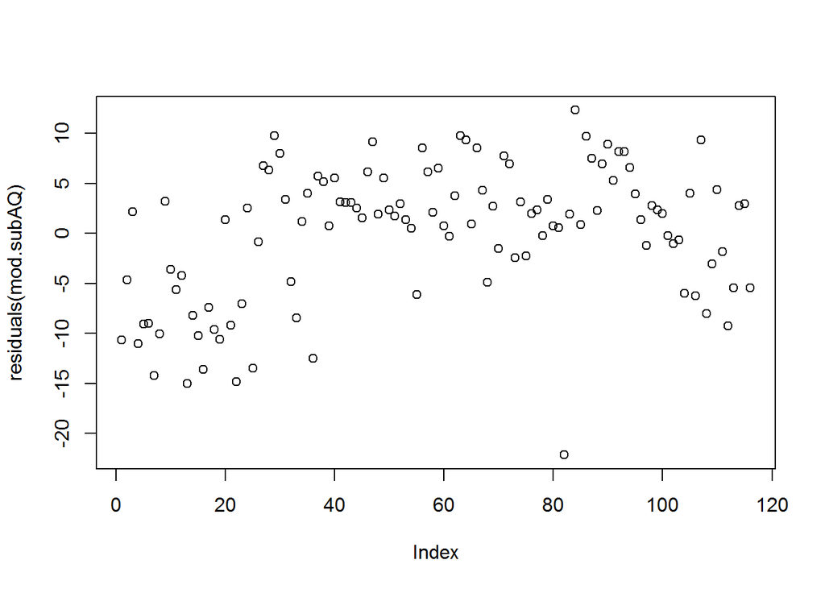

```r
plot(residuals(mod.subAQ))
```

It looks like there might be a slight autocorrelation in the residuals.

```r
dwtest(mod.subAQ, alternative=c("two.sided"))
```

```
##
##  Durbin-Watson test
##
## data:  mod.subAQ
## DW = 1.1833, p-value = 7.276e-06
## alternative hypothesis: true autocorrelation is not 0
```

In fact, there is.

## Homoscedasticity

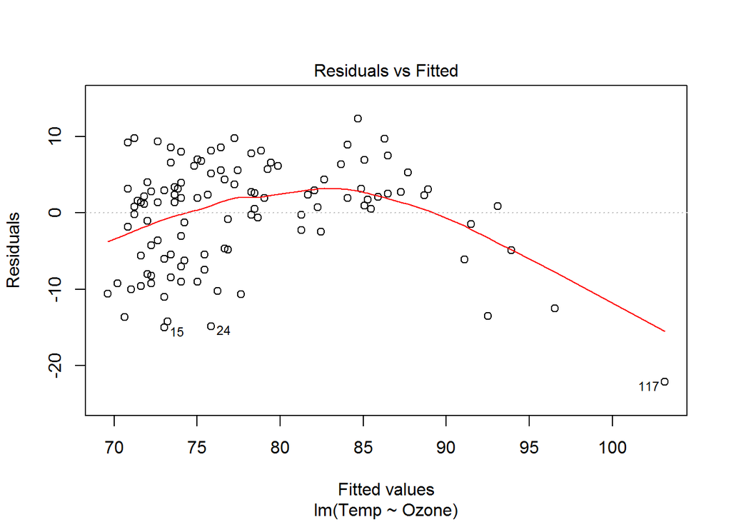

```r
plot(mod.subAQ, which=c(1))
```

The variance of the residuals looks like it is not evenly distributed throughout the plot - we expect our model to fail homoscedasticity.

```r
bptest(mod.subAQ)
```

```
##
##  studentized Breusch-Pagan test
##
## data:  mod.subAQ
## BP = 3.2346, df = 1, p-value = 0.0721
```

With a p slightly greater than 0.05, we can’t conclude with confidence that our risiduals fail homoscedasticity. Thus our data pass this requirement.

## Normality

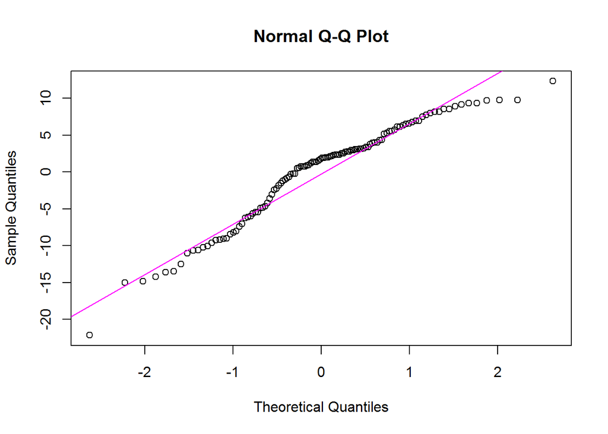

```r
qqnorm(residuals(mod.subAQ))
qqline(residuals(mod.subAQ), col="magenta")
```

Based on our qq-plot of the residuals, we expect our residuals to fail normality.

```r
shapiro.test(residuals(mod.subAQ))
```

```
##
##  Shapiro-Wilk normality test
##
## data:  residuals(mod.subAQ)
## W = 0.94867, p-value = 0.000226
```

We see that our residuals are not normally distributed.